# ActivityMonitoring

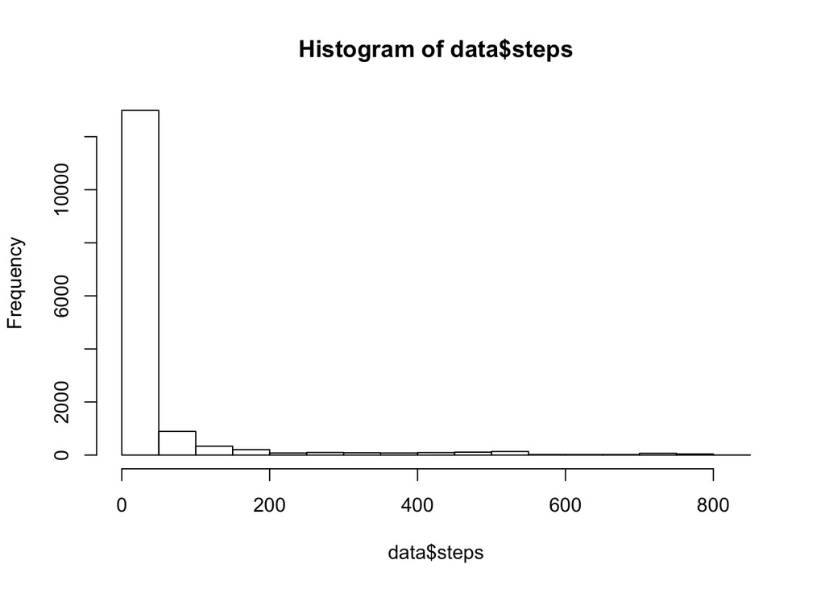

```r
hist(data$steps)
```

```r
mean(data$steps, na.rm = T)
```

```
## [1] 37.38
```

```r
mean(data2$steps)
```

```
## [1] 37.81
```

```r
median(data$steps, na.rm = T)
```

```
## [1] 0
```

```r
median(data2$steps)
```

```
## [1] 0
```

```r
TotalNrSteps = sum(data2$steps)
BeforeNRSteps = sum(data$steps, na.rm = T)
```

The difference between the means is roughly 0.5. The median remains the same. The total number of steps is 664277.8 after the correction as opposed to 570608 before the correction.

4. Are there differences in activity patterns between weekdays and weekends?

For this part the weekdays() function may be of some help here. Use the dataset with the filled-in missing values for this part.

Create a new factor variable in the dataset with two levels – “weekday” and “weekend” indicating whether a given date is a weekday or weekend day.

Make a panel plot containing a time series plot (i.e. type = “l”) of the 5-minute interval (x-axis) and the average number of steps taken, averaged across all weekday days or weekend days (y-axis).

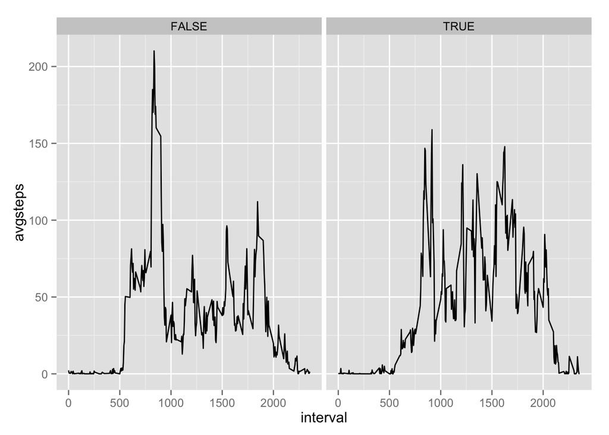

```r
library(ggplot2)
data2$weekdays = weekdays(as.Date(data2$date))
data2$weekends = data2$weekdays == "Sunday" | data2$weekdays == "Saturday"
ByDay = summarize(group_by(data2, weekends), avgsteps = mean(steps))

ByDay_and_Interval = summarize(group_by(data2, weekends, interval), avgsteps = mean(steps))

qplot(interval, avgsteps, data = ByDay_and_Interval, geom = "line") + facet_grid(~weekends)
```

Comparing the results on weekdays or weekends, but person is more active on the weekends (42.7 mean as opposed to 36.04 over the week)